# ==========================

# Univariate Plots Section

```
## 'data.frame':    4898 obs. of  12 variables:
##  $ fixed.acidity       : num  7 6.3 8.1 7.2 7.2 8.1 6.2 7 6.3 8.1 ...
##  $ volatile.acidity    : num  0.27 0.3 0.28 0.23 0.23 0.28 0.32 0.27 0.3 0.22 ...
##  $ citric.acid         : num  0.36 0.34 0.4 0.32 0.32 0.4 0.16 0.36 0.34 0.43 ...
##  $ residual.sugar      : num  20.7 1.6 6.9 8.5 8.5 6.9 7 20.7 1.6 1.5 ...
##  $ chlorides           : num  0.045 0.049 0.05 0.058 0.058 0.05 0.045 0.045 0.049 0.044 ...
##  $ free.sulfur.dioxide : num  45 14 30 47 47 30 30 45 14 28 ...
##  $ total.sulfur.dioxide: num  170 132 97 186 186 97 136 170 132 129 ...
##  $ density             : num  1.001 0.994 0.995 0.996 0.996 ...
##  $ pH                  : num  3 3.3 3.26 3.19 3.19 3.26 3.18 3 3.3 3.22 ...
##  $ sulphates           : num  0.45 0.49 0.44 0.4 0.4 0.44 0.47 0.45 0.49 0.45 ...
##  $ alcohol             : num  8.8 9.5 10.1 9.9 9.9 10.1 9.6 8.8 9.5 11 ...
##  $ quality             : int  6 6 6 6 6 6 6 6 6 6 ...
```

```
##  fixed.acidity    volatile.acidity  citric.acid     residual.sugar
##  Min.   : 3.800   Min.   :0.0800   Min.   :0.0000   Min.   : 0.600
##  1st Qu.: 6.300   1st Qu.:0.2100   1st Qu.:0.2700   1st Qu.: 1.700
##  Median : 6.800   Median :0.2600   Median :0.3200   Median : 5.200
##  Mean   : 6.855   Mean   :0.2782   Mean   :0.3342   Mean   : 6.391
##  3rd Qu.: 7.300   3rd Qu.:0.3200   3rd Qu.:0.3900   3rd Qu.: 9.900
##  Max.   :14.200   Max.   :1.1000   Max.   :1.6600   Max.   :65.800
##    chlorides       free.sulfur.dioxide total.sulfur.dioxide
##  Min.   :0.00900   Min.   :  2.00      Min.   :  9.0
##  1st Qu.:0.03600   1st Qu.: 23.00      1st Qu.:108.0
##  Median :0.04300   Median : 34.00      Median :134.0
##  Mean   :0.04577   Mean   : 35.31      Mean   :138.4
##  3rd Qu.:0.05000   3rd Qu.: 46.00      3rd Qu.:167.0
##  Max.   :0.34600   Max.   :289.00      Max.   :440.0
##     density             pH          sulphates         alcohol
##  Min.   :0.9871   Min.   :2.720   Min.   :0.2200   Min.   : 8.00
##  1st Qu.:0.9917   1st Qu.:3.090   1st Qu.:0.4100   1st Qu.: 9.50
##  Median :0.9937   Median :3.180   Median :0.4700   Median :10.40
##  Mean   :0.9940   Mean   :3.188   Mean   :0.4898   Mean   :10.51
##  3rd Qu.:0.9961   3rd Qu.:3.280   3rd Qu.:0.5500   3rd Qu.:11.40
##  Max.   :1.0390   Max.   :3.820   Max.   :1.0800   Max.   :14.20
##     quality
##  Min.   :3.000
##  1st Qu.:5.000
##  Median :6.000
##  Mean   :5.878
##  3rd Qu.:6.000
##  Max.   :9.000
```

All input variables are of numeric type.

```
##
##    3    4    5    6    7    8    9
##   20  163 1457 2198  880  175    5
```

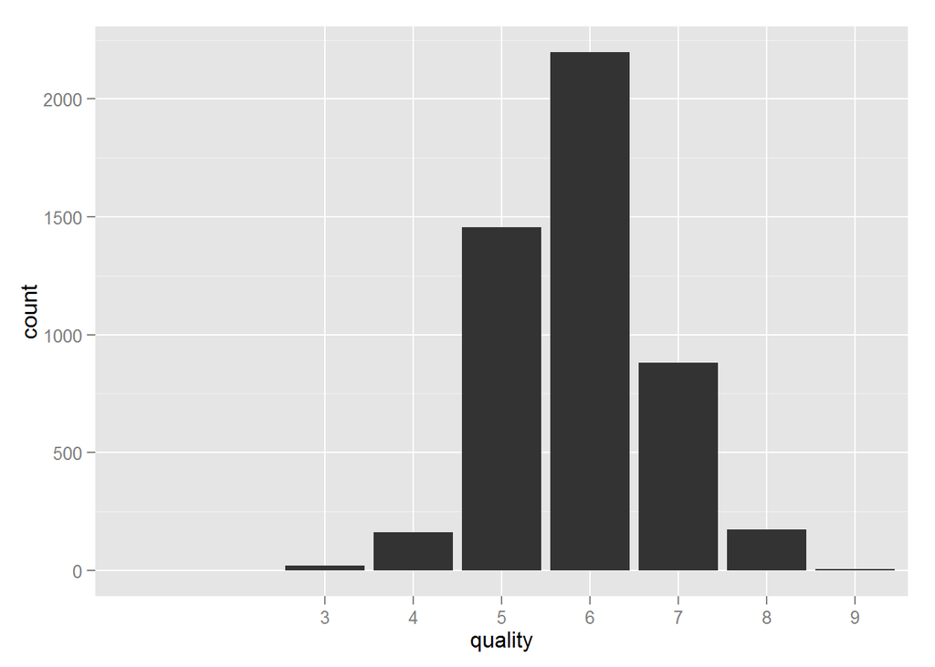

Most wines have a quality from 5 to 7.

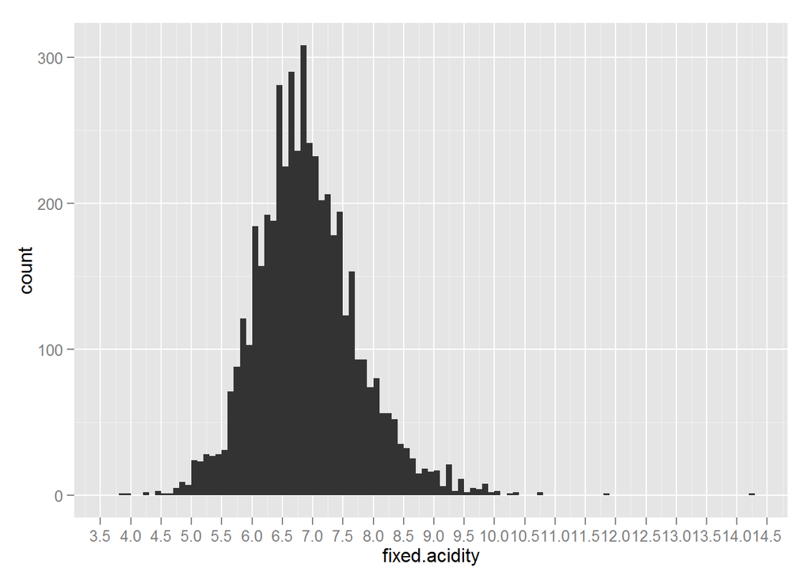

There are some outliers which are very close or bigger than 12. Dispite the outliers, the distribution is more or less normal with a mean between 6.5 and 7.0.

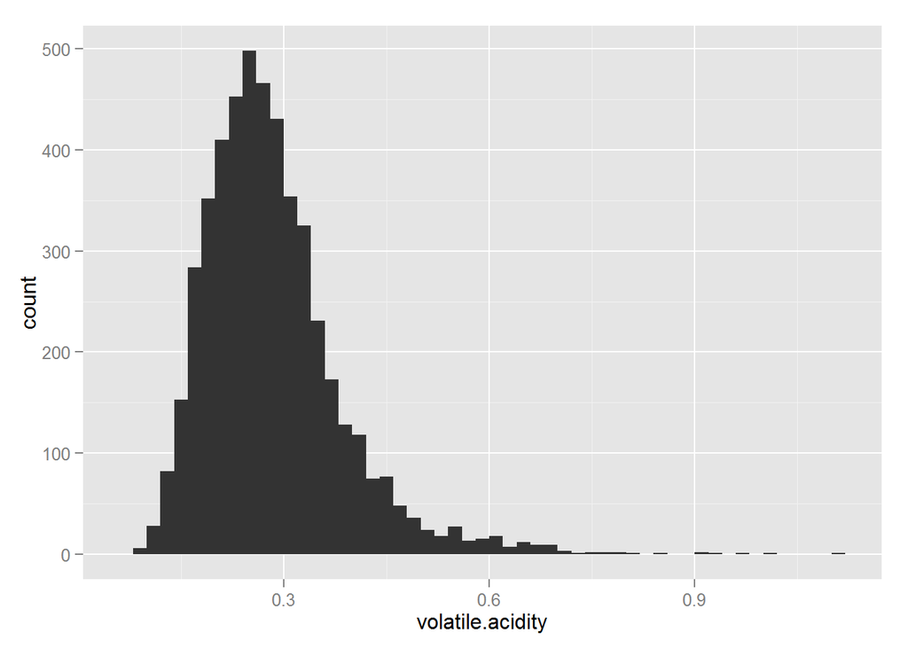

The distribution is a little skewed on right side. The 3 quaters of values are less than 0.32 while there are some very big values (bigger than 0.9).

```
## [1] 0.00 1.66
```

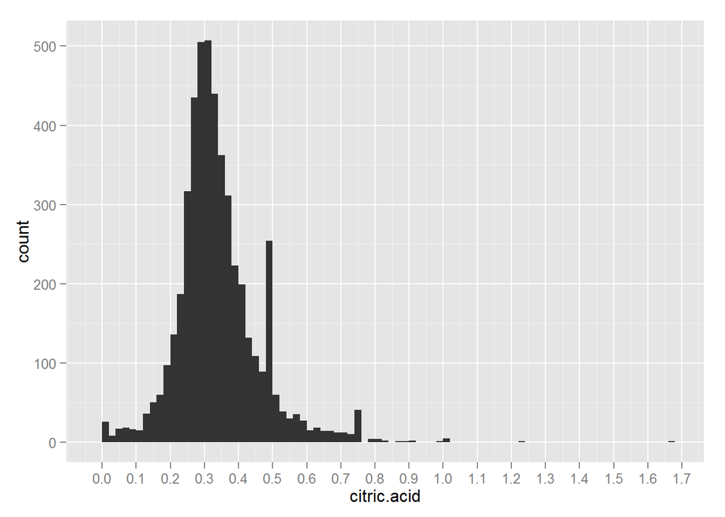

Citric.acid has a mean value between 0.3 and 0.35. There are 0 values and outliers(the max is 1.66). We observed a odd spike close to 0.5.

I want to take a look at the whole acidity value of a white wine. I got this total acid by using following formula : acid.total = fixed.acidity + volatile.acidity + citric.acid

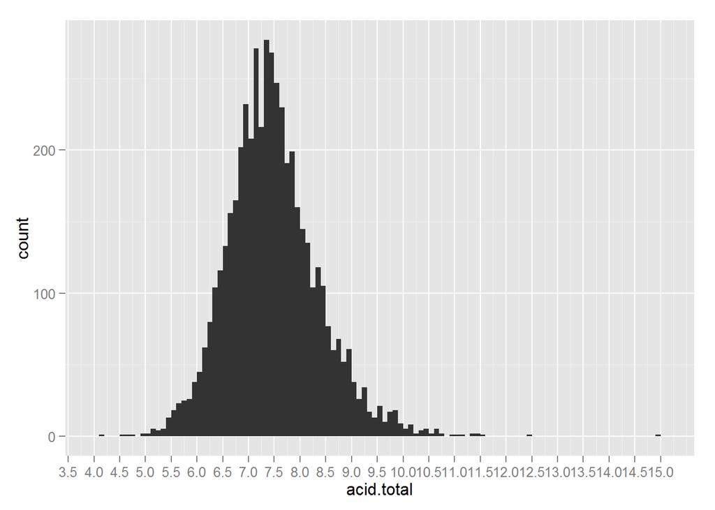

The total acid seems to be normal distributed if we don’t take into account the outliers close to 12 and 15. We can see the its distribution doesn’t seem to be much different from the one of fixed.acidity.

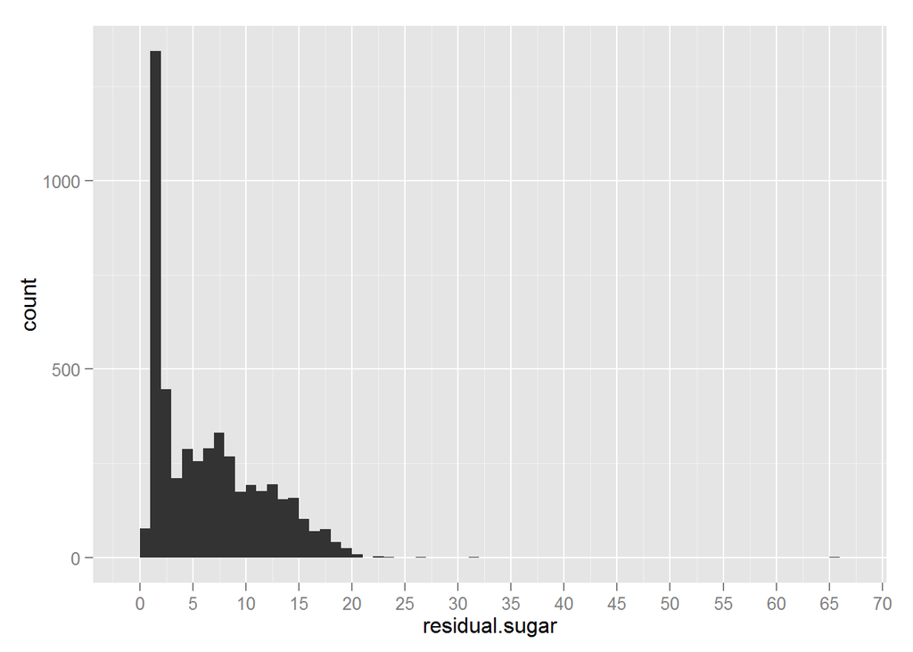

[output not shown]

```
##    Min. 1st Qu.  Median    Mean 3rd Qu.    Max.
##   0.600   1.700   5.200   6.391   9.900  65.800
```

There are large numbers of values between 1 to 2 with few extreme values which draw drastically the distribution to be right skewed. We will do some limitation on x scale to focus on the essential part. By the way, I’m also wondering and interested why there are those extreme outliers.

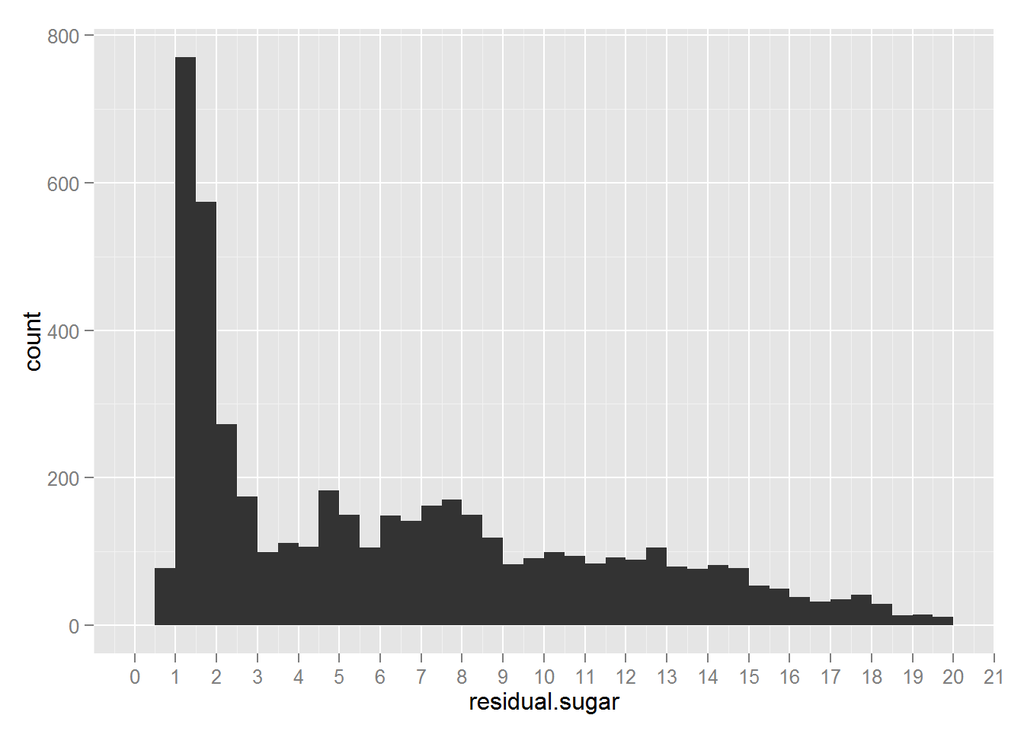

Compared to the average count over 0 to 20, there are too much values between 1 and 2. I decided to do a square root transformation of the x scale.

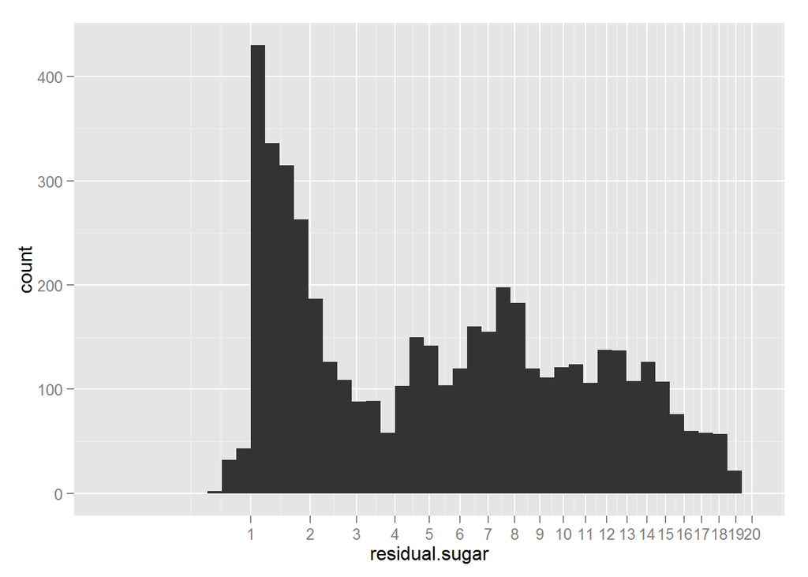

Now there are a little more details between 1 to 2 and we observed a bimodal or perhaps trimodal distribution.

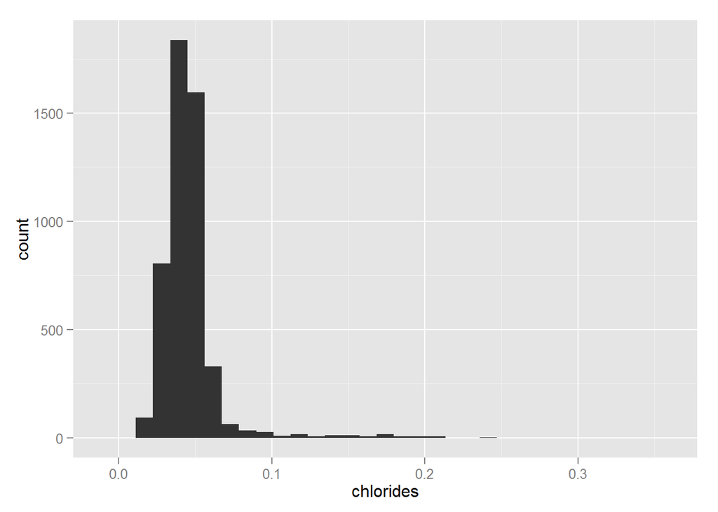

```
##    Min. 1st Qu.  Median    Mean 3rd Qu.    Max.
## 0.00900 0.03600 0.04300 0.04577 0.05000 0.34600
```

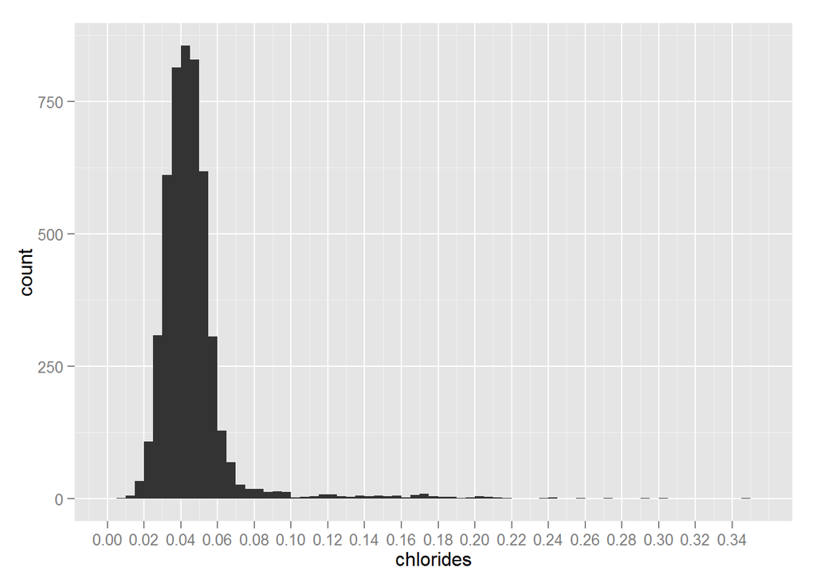

```
## [1]   2 289
```

```
##
##     2     3     4     5     6     7     8     9    10    11  11.5    12
##     1    10    11    25    32    25    35    29    55    45     1    51
##    13    14    15  15.5    16    17    18    19  19.5    20    21    22
##    55    68    79     1    58    89    80    84     1   101    93   102
##    23  23.5    24    25    26    27    28  28.5    29    30  30.5    31
##   110     1   118   111   129    99   112     1   160    99     1   132
##    32    33    34    35  35.5    36    37    38  38.5    39  39.5    40
##   109   112   128   129     2   127   111   102     1    89     1   103
##  40.5    41  41.5    42  42.5    43  43.5    44  44.5    45    46    47
##     1   104     2    86     1    63     1    75     4   101    64    91
##    48  48.5    49    50  50.5    51  51.5    52  52.5    53    54    55
##    66     7    82    64     2    54     1    72     4    68    61    58
##    56    57    58    59  59.5    60  60.5    61  61.5    62    63    64
##    42    44    37    39     2    38     2    47     1    29    30    23
##  64.5    65    66    67    68    69    70  70.5    71    72    73  73.5
##     1    14    17    22    24    17    11     1     5     6     8     4
##    74    75    76    77  77.5    78    79  79.5    80    81    82  82.5
##     5     7     5     5     1     4     2     4     1     7     2     1
##    83    85    86    87    88    89    93    95    96    97    98   101
##     4     2     2     4     1     1     1     1     3     1     3     2
##   105   108   110   112 118.5 122.5   124   128   131 138.5 146.5   289
##     2     3     1     1     1     1     1     1     1     1     1     1
```

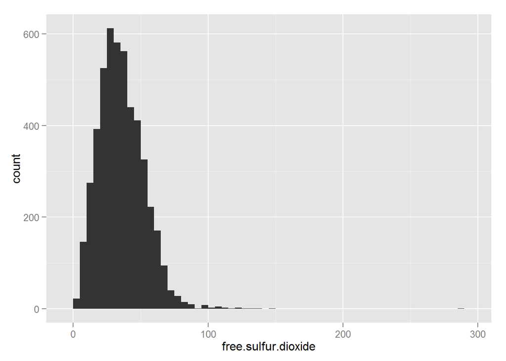

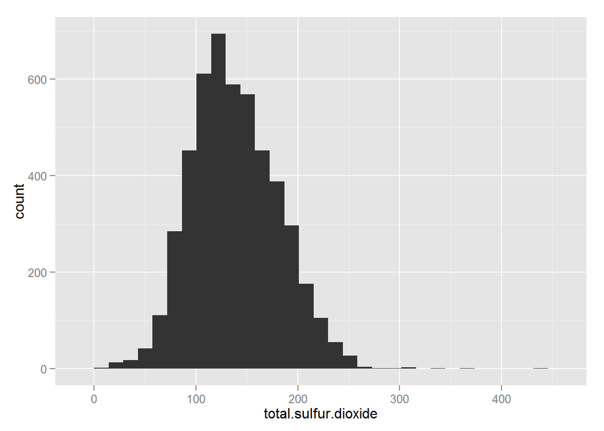

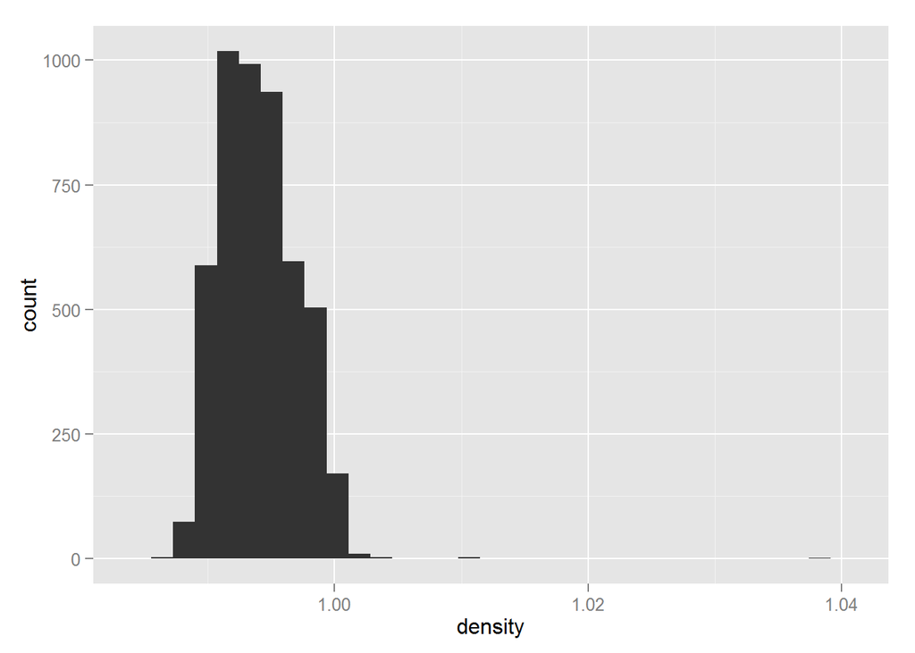

```
##    Min. 1st Qu.  Median    Mean 3rd Qu.    Max.
##  0.9871  0.9917  0.9937  0.9940  0.9961  1.0390
```

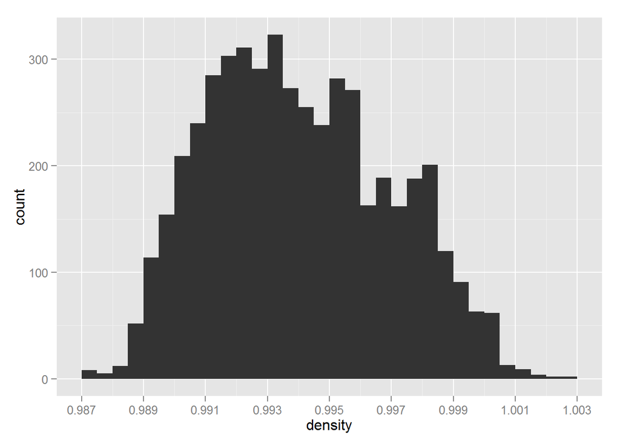

Most values are between 0.989 and 1. On average, the density of white wine is less than water.

```
## [1] 2.72 3.82
```

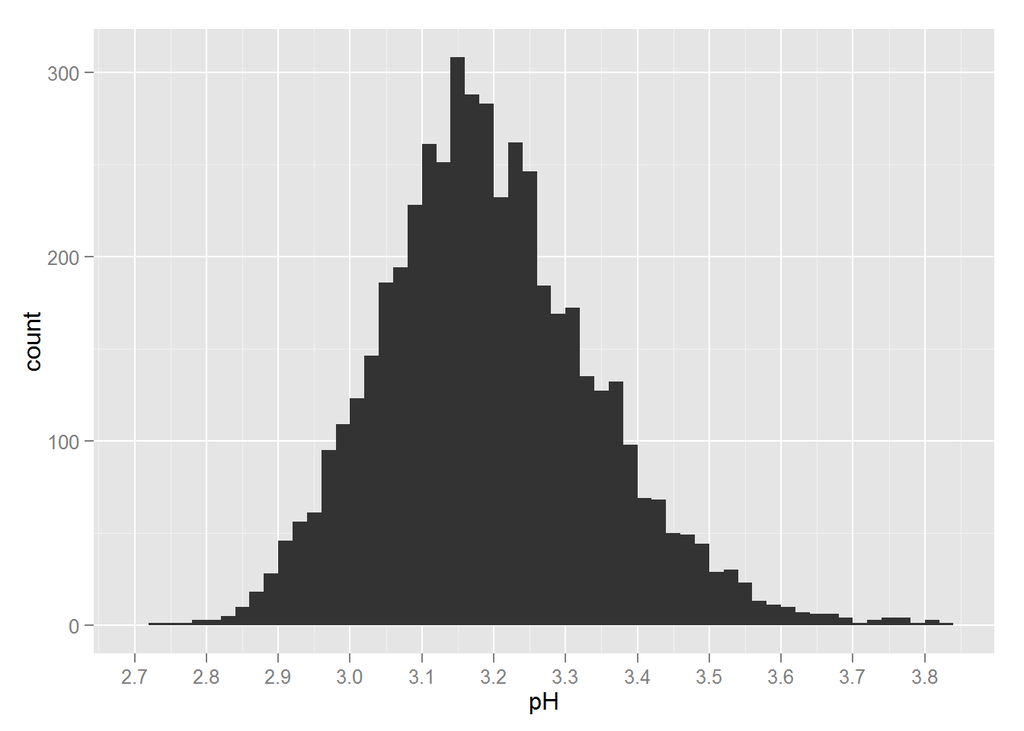

The mean PH is around 3.2, which is consistent with the acidity of wine

```
## [1] 0.22 1.08
```

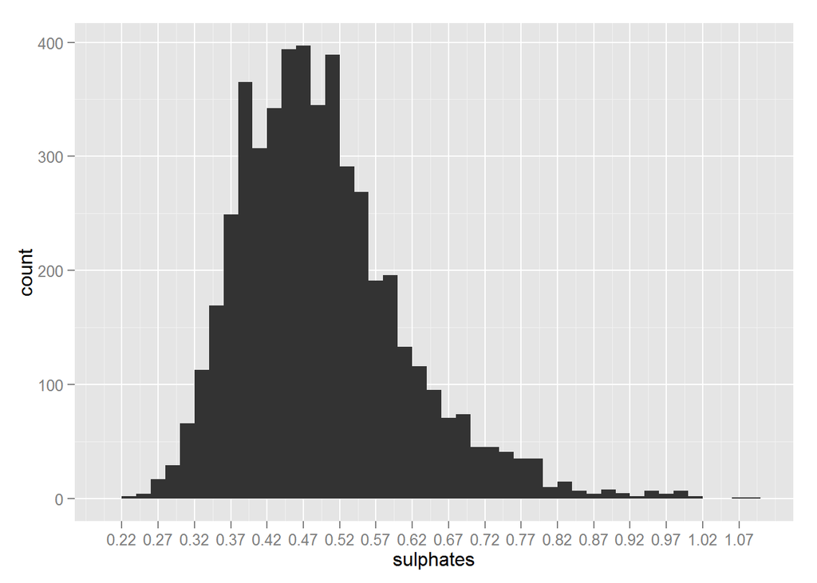

[output not shown]

```
##    Min. 1st Qu.  Median    Mean 3rd Qu.    Max.
##    8.00    9.50   10.40   10.51   11.40   14.20
```

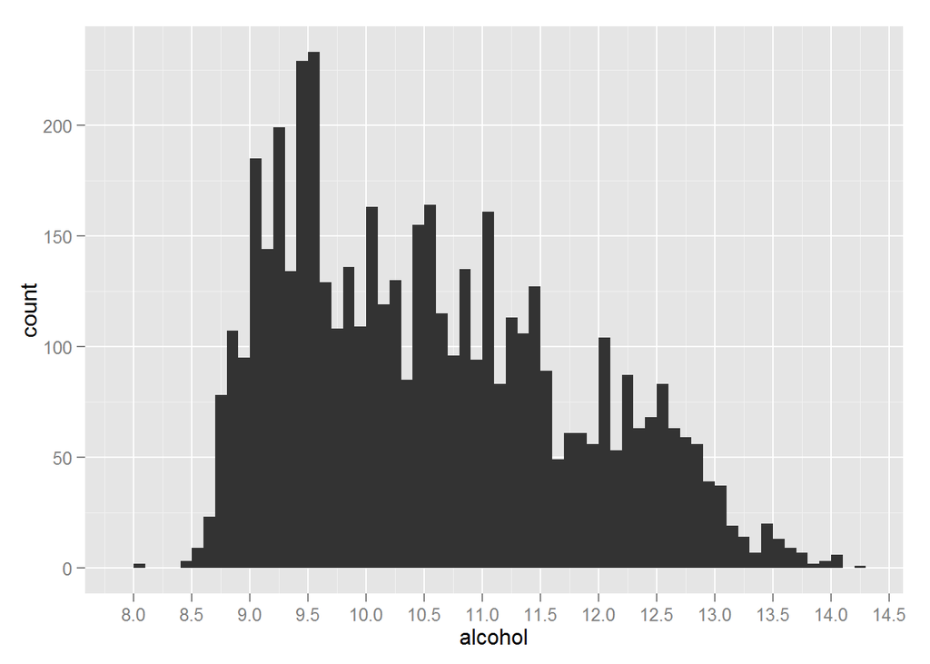

The distribution of alcohol is evident, it seems a little like a plateau distribution. There are servals peaks, the most obvious one is around 9.5.

# Univariate Analysis

### What is the structure of your dataset?

There are 4898 white wines in the dataset with 12 features (fixed.acidity, volatile.acidity, citric.acid, residual.sugar, chlorides, free.sulfur.dioxide, total.sulfur.dioxide, density, pH, sulphates, alcohol and quality). Except quality, all others variables are of numeric(float) type. Quality is of type integer.

Other observations: Most white wines have a quality from 5 to 7. On acidity level, mean fixed.acidit for white wine is around 6.9, volatile.acidity aound 0.28 and citric.acid aound 0.33. The median residual sugar for a white wine is 5.2 while the max residual sugar can be 65.8. About 75% of white wines chlorides less than 0.05. Most white wines have a density less than water, and they are acid with a mean PH around 3.2. The contained alcohol value is essentially between 8.5 and 14.

### What is/are the main feature(s) of interest in your dataset?

The main feature of interest in the data set is the quality. I’d like to determine which features or combination of features are best for predicting the quality of a white wine.

### What other features in the dataset do you think will help support your investigation into your feature(s) of interest?

fixed.acidity, volatile.acidity, citric.acid, residual.sugar, chlorides, and alcohol likely contribute to the quality of a white wine.

### Did you create any new variables from existing variables in the dataset?

Yes, I create a acid.total variable by adding fixed.acidity, volatile.acidity and citric.acid together, beacause I want to explore the relationship between acidity, sugar and chlorides in next sections.

### Of the features you investigated, were there any unusual distributions? Did you perform any operations on the data to tidy, adjust, or change the form of the data? If so, why did you do this?

The residual.sugar variable has too extreme outliers, so I used x limitation to be able to focus on the essential part. In addition, there are too many values between 1 and 2, which reduce the readability of visualisation, so I did a square root transformation on x scale to zoom into this data crowded part.

# Bivariate Plots Section

first, I want to explore the all other features against the feature of interest(quality).

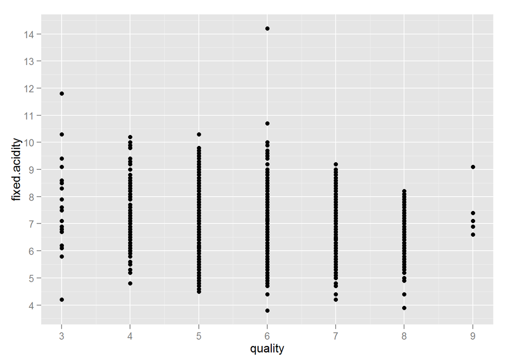

As the quality is of integer type, I will add the jitter effect to disperse a little the ligned points, as well as certain transparency to reduce the overplotting.

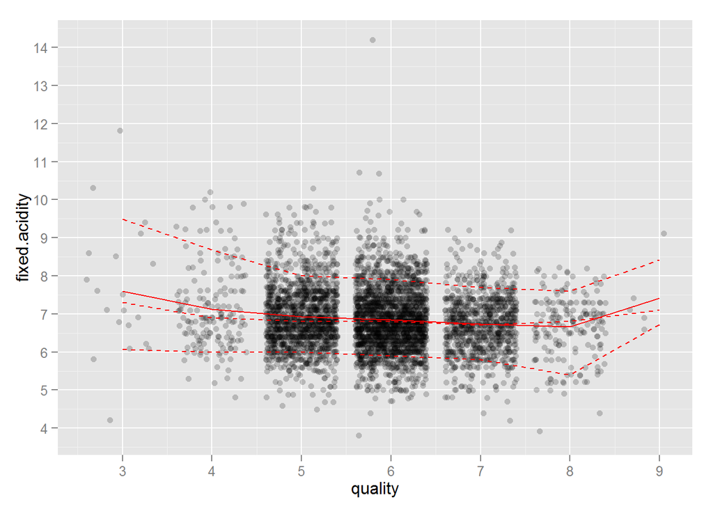

The mean value is quite stable for the wine quality of 5,6 and 7 which constite 90% of all wine observations. We noted for the quality 3, the fixed.acidity value is quite dispersed.

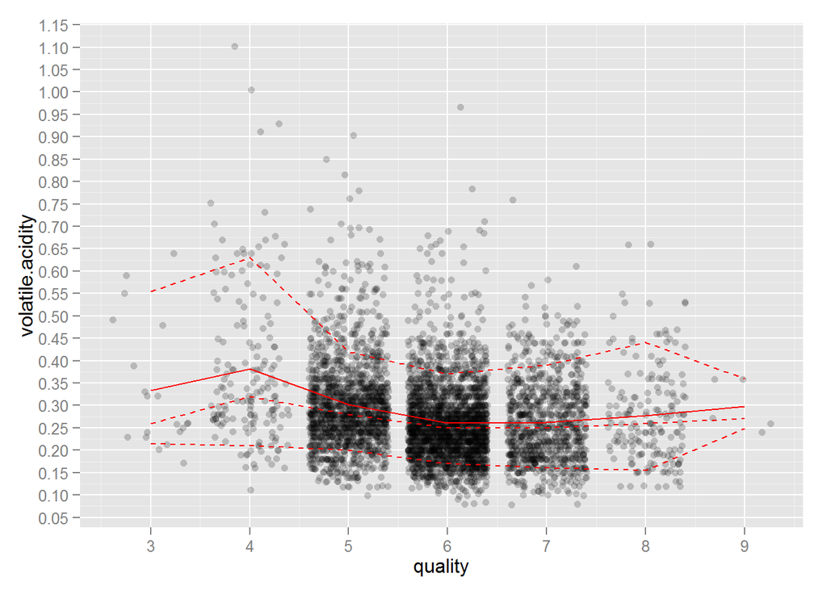

We observed a slight decline of point dispersion when the quality of white wine increase. The mean volatile.acidity value also seems to slightly decline when the wine quality pass from 5 to 6.

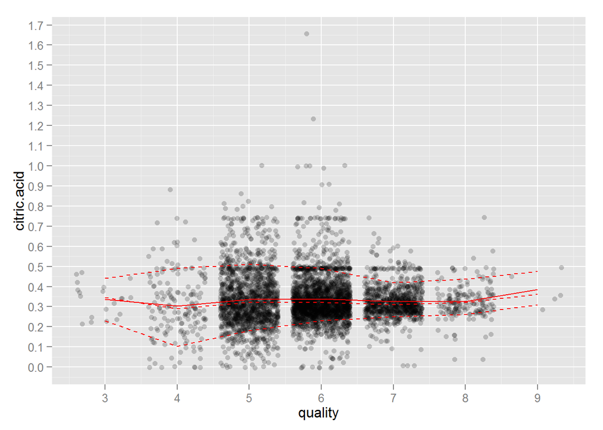

We noted odd cluster on the value of 0.5 of citric.acid for wines of quality 5, 6 and 7. I’m not clear about why there comes such cluster on a particular value. Maybe 0.5 citric.acid is a standard or regular value in the white wine domain.

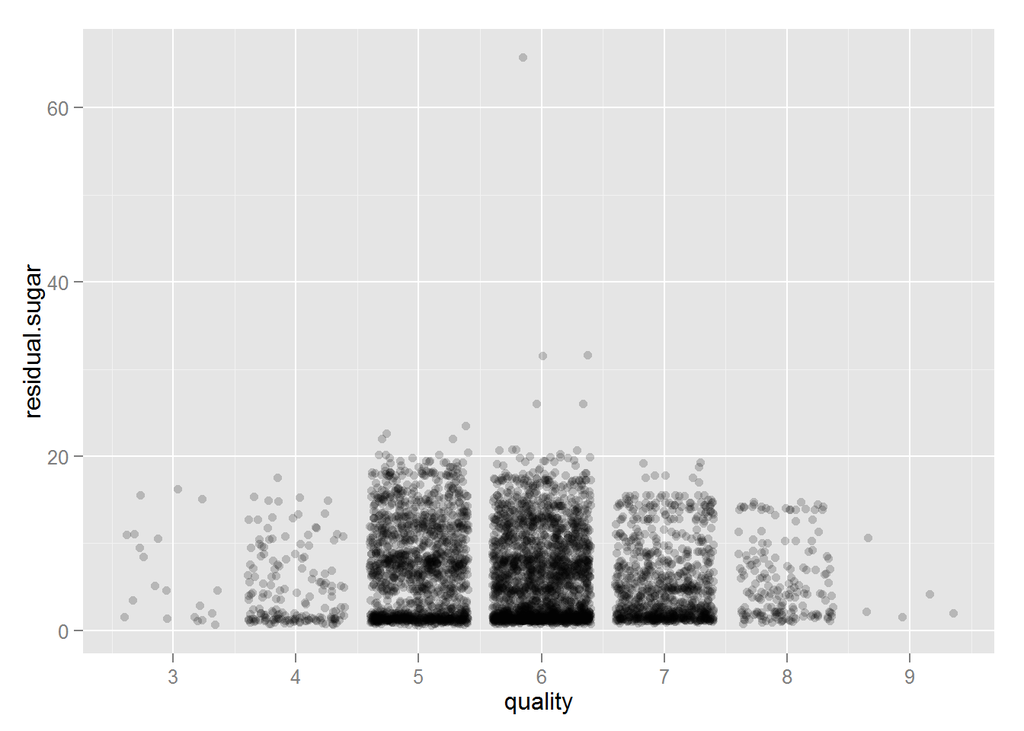

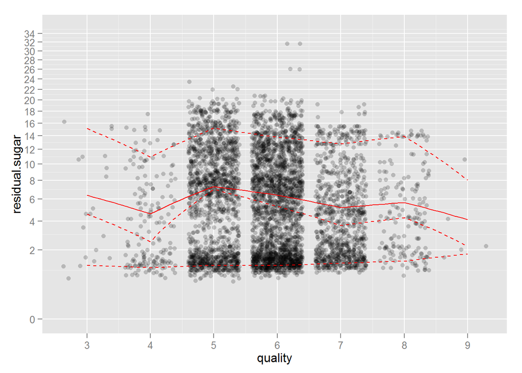

We can see even after square root transformation on residual.sugar scale, there are still many points between 1 and 2, and this occurs for almost all different levels of quality of white wine. While we also observed a clear trend that for most wines (quality of 5,6 and 7), the better quality of wine, the less residual sugar.

I also want to take a look at the box plot of the residual sugar. As the quality is of type integar, it’s feasible by converting the quality into a categorical variable. While I choose to create a new factor variable quality.factor based on quality.

```r
wine$quality.factor = factor(wine$quality)
str(wine)
```

```
## 'data.frame':    4898 obs. of  14 variables:
##  $ fixed.acidity       : num  7 6.3 8.1 7.2 7.2 8.1 6.2 7 6.3 8.1 ...
##  $ volatile.acidity    : num  0.27 0.3 0.28 0.23 0.23 0.28 0.32 0.27 0.3 0.22 ...
##  $ citric.acid         : num  0.36 0.34 0.4 0.32 0.32 0.4 0.16 0.36 0.34 0.43 ...
##  $ residual.sugar      : num  20.7 1.6 6.9 8.5 8.5 6.9 7 20.7 1.6 1.5 ...
##  $ chlorides           : num  0.045 0.049 0.05 0.058 0.058 0.05 0.045 0.045 0.049 0.044 ...
##  $ free.sulfur.dioxide : num  45 14 30 47 47 30 30 45 14 28 ...
##  $ total.sulfur.dioxide: num  170 132 97 186 186 97 136 170 132 129 ...
##  $ density             : num  1.001 0.994 0.995 0.996 0.996 ...
##  $ pH                  : num  3 3.3 3.26 3.19 3.19 3.26 3.18 3 3.3 3.22 ...
##  $ sulphates           : num  0.45 0.49 0.44 0.4 0.4 0.44 0.47 0.45 0.49 0.45 ...
##  $ alcohol             : num  8.8 9.5 10.1 9.9 9.9 10.1 9.6 8.8 9.5 11 ...
##  $ quality             : int  6 6 6 6 6 6 6 6 6 6 ...
##  $ acid.total          : num  7.63 6.94 8.78 7.75 7.75 8.78 6.68 7.63 6.94 8.75 ...
##  $ quality.factor      : Factor w/ 7 levels "3","4","5","6",..: 4 4 4 4 4 4 4 4 4 4 ...
```

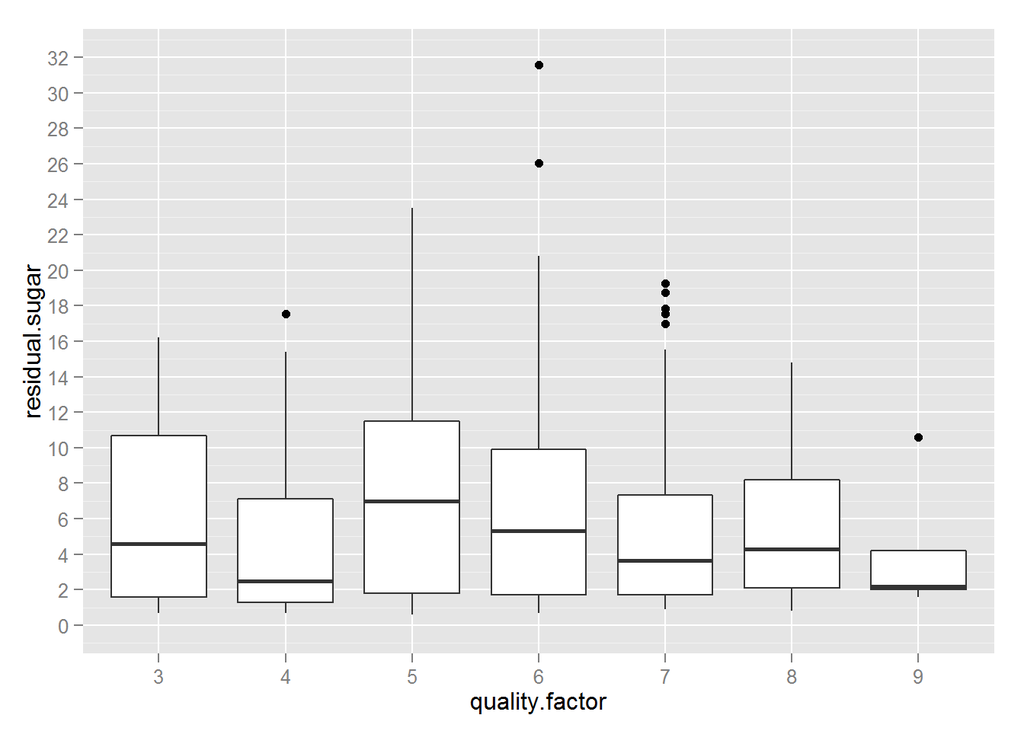

The box plotting confirmed what we observed in previous plot. In addition, we found that for most wines, the variation of residual sugar tends to descrease when the quality of wine increase.

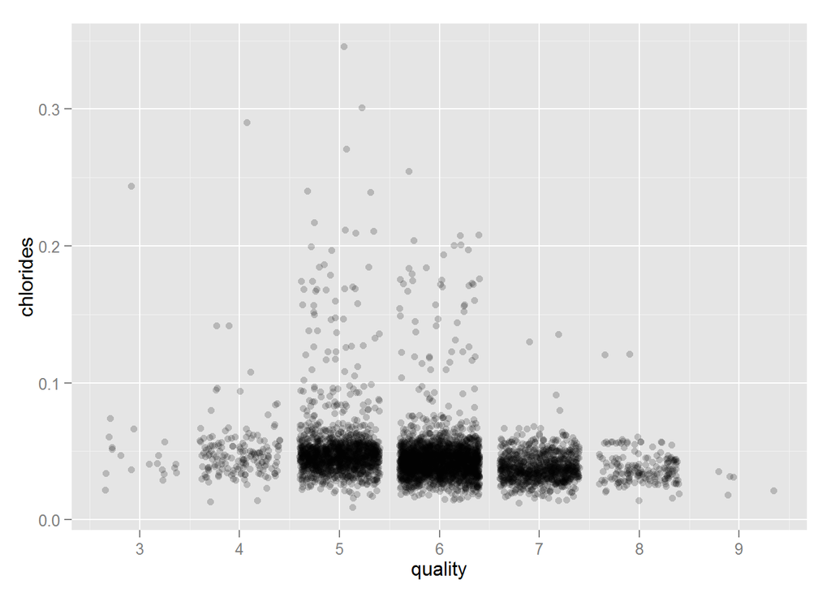

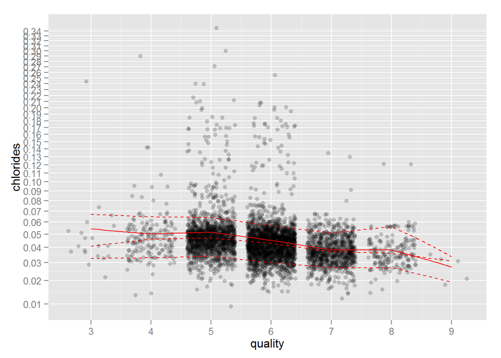

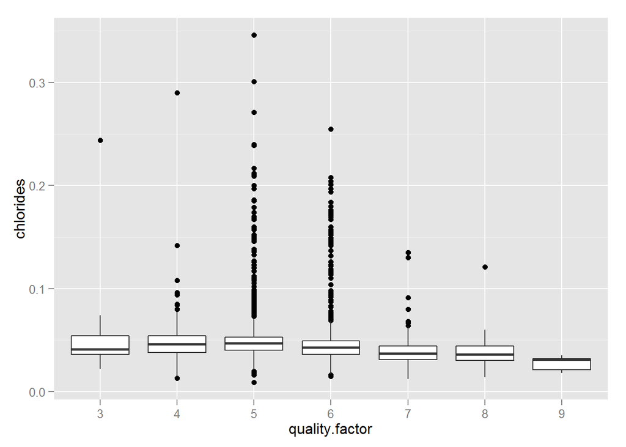

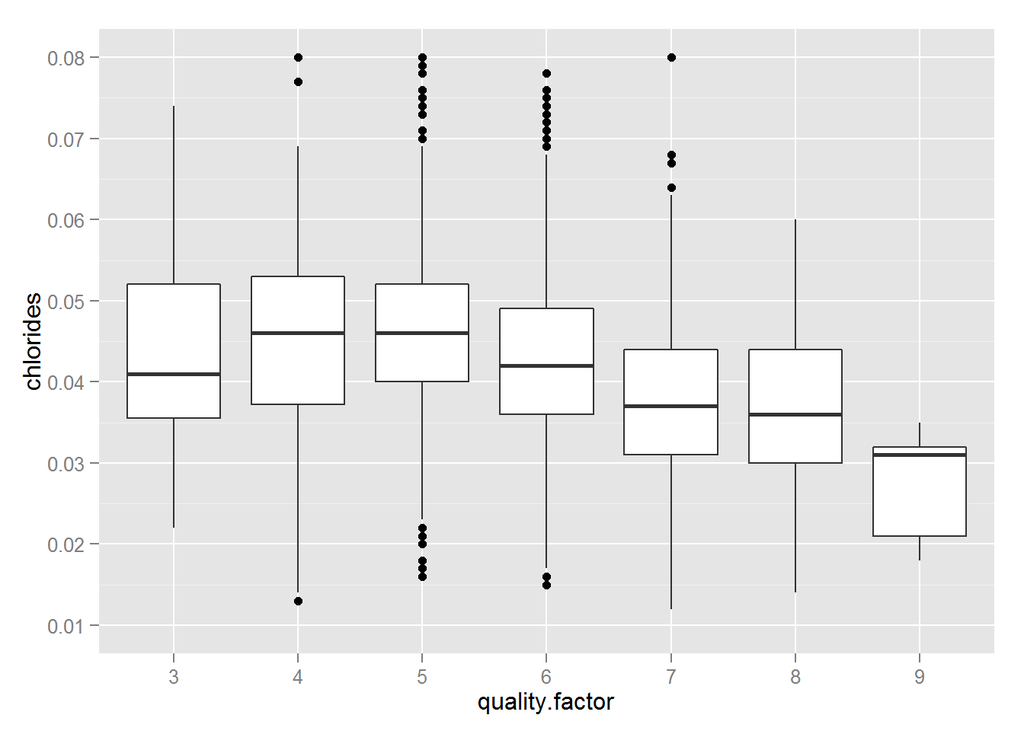

There are many outliers. We can see clearly that the quality of wine increase when the chlorides value descrease.

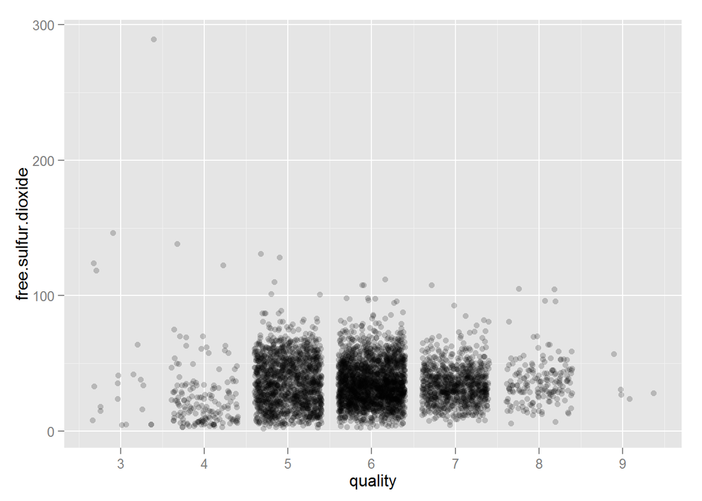

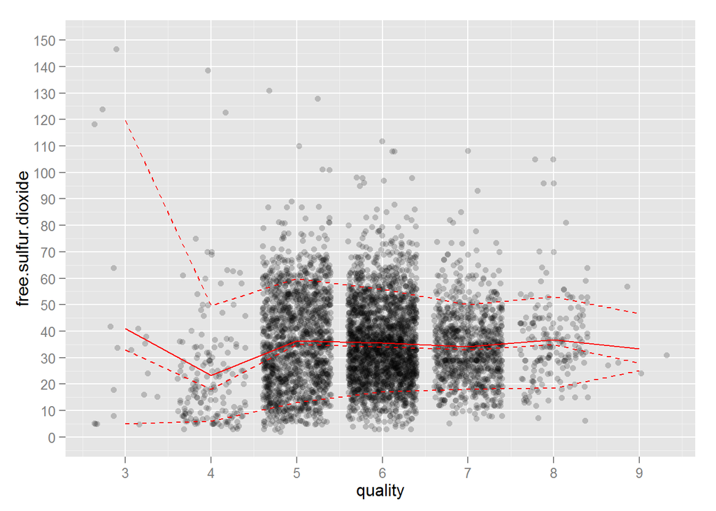

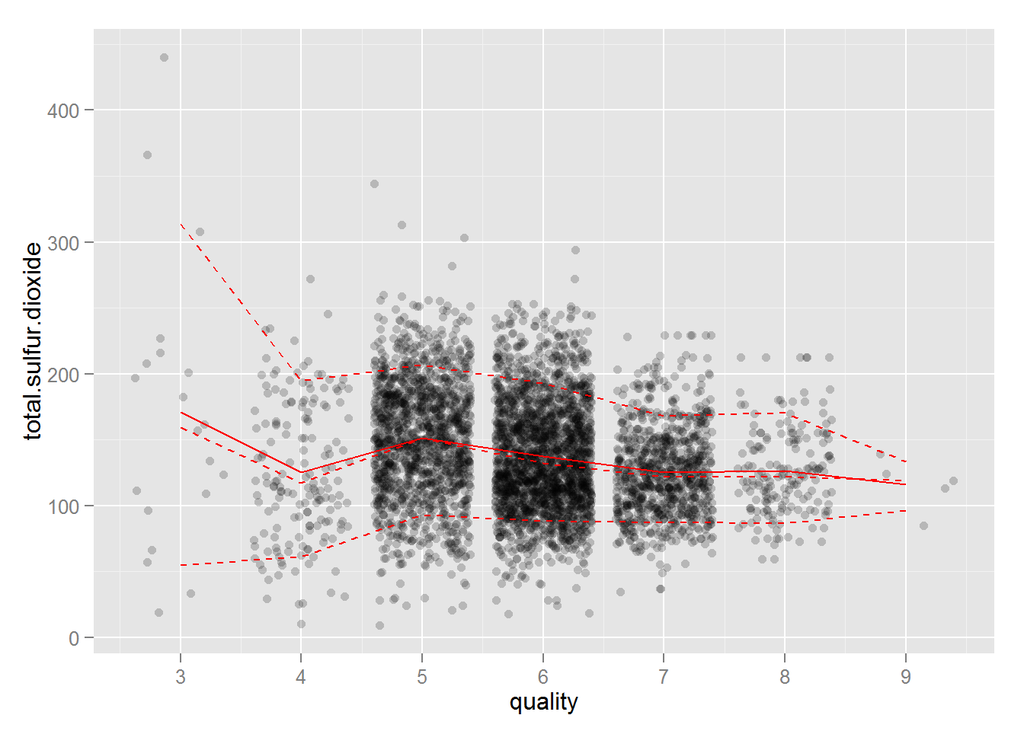